# Risk Factor Analysis

## Outcome Variable

**Outcome Variable:** stunted

## Predictor Variables

**Intervention Variable:** nrooms

**Adjustment Set:**

unadjusted

## Stratifying Variables

The analysis was stratified on these variable(s):

- agecat
- studyid
- country

## Data Summary

| agecat | studyid | country | nrooms | stunted | n_cell | n |
| --- | --- | --- | --- | --- | --- | --- |
| Birth | CMC-V-BCS-2002 | INDIA | 4+ | 0 | 4 | 92 |
| Birth | CMC-V-BCS-2002 | INDIA | 4+ | 1 | 1 | 92 |
| Birth | CMC-V-BCS-2002 | INDIA | 1 | 0 | 32 | 92 |
| Birth | CMC-V-BCS-2002 | INDIA | 1 | 1 | 6 | 92 |
| Birth | CMC-V-BCS-2002 | INDIA | 2 | 0 | 22 | 92 |
| Birth | CMC-V-BCS-2002 | INDIA | 2 | 1 | 7 | 92 |
| Birth | CMC-V-BCS-2002 | INDIA | 3 | 0 | 17 | 92 |
| Birth | CMC-V-BCS-2002 | INDIA | 3 | 1 | 3 | 92 |
| Birth | COHORTS | INDIA | 4+ | 0 | 84 | 4769 |
| Birth | COHORTS | INDIA | 4+ | 1 | 8 | 4769 |
| Birth | COHORTS | INDIA | 1 | 0 | 2705 | 4769 |
| Birth | COHORTS | INDIA | 1 | 1 | 420 | 4769 |
| Birth | COHORTS | INDIA | 2 | 0 | 1263 | 4769 |
| Birth | COHORTS | INDIA | 2 | 1 | 122 | 4769 |
| Birth | COHORTS | INDIA | 3 | 0 | 152 | 4769 |
| Birth | COHORTS | INDIA | 3 | 1 | 15 | 4769 |
| Birth | CONTENT | PERU | 4+ | 0 | 1 | 2 |
| Birth | CONTENT | PERU | 4+ | 1 | 0 | 2 |
| Birth | CONTENT | PERU | 1 | 0 | 0 | 2 |
| Birth | CONTENT | PERU | 1 | 1 | 0 | 2 |
| Birth | CONTENT | PERU | 2 | 0 | 1 | 2 |
| Birth | CONTENT | PERU | 2 | 1 | 0 | 2 |
| Birth | CONTENT | PERU | 3 | 0 | 0 | 2 |
| Birth | CONTENT | PERU | 3 | 1 | 0 | 2 |
| Birth | GMS-Nepal | NEPAL | 4+ | 0 | 276 | 696 |
| Birth | GMS-Nepal | NEPAL | 4+ | 1 | 45 | 696 |
| Birth | GMS-Nepal | NEPAL | 1 | 0 | 42 | 696 |
| Birth | GMS-Nepal | NEPAL | 1 | 1 | 7 | 696 |
| Birth | GMS-Nepal | NEPAL | 2 | 0 | 113 | 696 |
| Birth | GMS-Nepal | NEPAL | 2 | 1 | 32 | 696 |

[output cut: 306 more lines]

The following strata were considered:

- agecat: 24 months, studyid: CMC-V-BCS-2002, country: INDIA
- agecat: 24 months, studyid: COHORTS, country: INDIA
- agecat: 24 months, studyid: CONTENT, country: PERU
- agecat: 24 months, studyid: GMS-Nepal, country: NEPAL
- agecat: 24 months, studyid: IRC, country: INDIA
- agecat: 24 months, studyid: MAL-ED, country: BANGLADESH
- agecat: 24 months, studyid: MAL-ED, country: BRAZIL
- agecat: 24 months, studyid: MAL-ED, country: INDIA
- agecat: 24 months, studyid: MAL-ED, country: NEPAL
- agecat: 24 months, studyid: MAL-ED, country: PERU
- agecat: 24 months, studyid: MAL-ED, country: SOUTH AFRICA
- agecat: 24 months, studyid: MAL-ED, country: TANZANIA, UNITED REPUBLIC OF
- agecat: 24 months, studyid: NIH-Crypto, country: BANGLADESH
- agecat: 24 months, studyid: PROVIDE, country: BANGLADESH
- agecat: 6 months, studyid: CMC-V-BCS-2002, country: INDIA
- agecat: 6 months, studyid: COHORTS, country: INDIA
- agecat: 6 months, studyid: CONTENT, country: PERU
- agecat: 6 months, studyid: GMS-Nepal, country: NEPAL
- agecat: 6 months, studyid: IRC, country: INDIA
- agecat: 6 months, studyid: MAL-ED, country: BANGLADESH
- agecat: 6 months, studyid: MAL-ED, country: BRAZIL
- agecat: 6 months, studyid: MAL-ED, country: INDIA
- agecat: 6 months, studyid: MAL-ED, country: NEPAL
- agecat: 6 months, studyid: MAL-ED, country: PERU
- agecat: 6 months, studyid: MAL-ED, country: SOUTH AFRICA
- agecat: 6 months, studyid: MAL-ED, country: TANZANIA, UNITED REPUBLIC OF
- agecat: 6 months, studyid: NIH-Crypto, country: BANGLADESH
- agecat: 6 months, studyid: PROVIDE, country: BANGLADESH
- agecat: Birth, studyid: CMC-V-BCS-2002, country: INDIA
- agecat: Birth, studyid: COHORTS, country: INDIA
- agecat: Birth, studyid: CONTENT, country: PERU
- agecat: Birth, studyid: GMS-Nepal, country: NEPAL
- agecat: Birth, studyid: IRC, country: INDIA
- agecat: Birth, studyid: MAL-ED, country: BANGLADESH
- agecat: Birth, studyid: MAL-ED, country: BRAZIL
- agecat: Birth, studyid: MAL-ED, country: INDIA
- agecat: Birth, studyid: MAL-ED, country: NEPAL
- agecat: Birth, studyid: MAL-ED, country: PERU
- agecat: Birth, studyid: MAL-ED, country: SOUTH AFRICA
- agecat: Birth, studyid: MAL-ED, country: TANZANIA, UNITED REPUBLIC OF
- agecat: Birth, studyid: NIH-Crypto, country: BANGLADESH
- agecat: Birth, studyid: PROVIDE, country: BANGLADESH

### Dropped Strata

Some strata were dropped due to rare outcomes:

- agecat: Birth, studyid: CMC-V-BCS-2002, country: INDIA
- agecat: Birth, studyid: CONTENT, country: PERU
- agecat: Birth, studyid: IRC, country: INDIA
- agecat: Birth, studyid: MAL-ED, country: BANGLADESH
- agecat: Birth, studyid: MAL-ED, country: BRAZIL
- agecat: Birth, studyid: MAL-ED, country: INDIA
- agecat: Birth, studyid: MAL-ED, country: NEPAL
- agecat: Birth, studyid: MAL-ED, country: PERU
- agecat: Birth, studyid: MAL-ED, country: SOUTH AFRICA
- agecat: Birth, studyid: MAL-ED, country: TANZANIA, UNITED REPUBLIC OF
- agecat: Birth, studyid: PROVIDE, country: BANGLADESH
- agecat: 6 months, studyid: CMC-V-BCS-2002, country: INDIA
- agecat: 6 months, studyid: CONTENT, country: PERU
- agecat: 6 months, studyid: IRC, country: INDIA
- agecat: 6 months, studyid: MAL-ED, country: BANGLADESH
- agecat: 6 months, studyid: MAL-ED, country: BRAZIL
- agecat: 6 months, studyid: MAL-ED, country: INDIA
- agecat: 6 months, studyid: MAL-ED, country: NEPAL
- agecat: 6 months, studyid: MAL-ED, country: SOUTH AFRICA
- agecat: 6 months, studyid: MAL-ED, country: TANZANIA, UNITED REPUBLIC OF
- agecat: 6 months, studyid: PROVIDE, country: BANGLADESH
- agecat: 24 months, studyid: CONTENT, country: PERU
- agecat: 24 months, studyid: MAL-ED, country: BANGLADESH
- agecat: 24 months, studyid: MAL-ED, country: BRAZIL
- agecat: 24 months, studyid: MAL-ED, country: TANZANIA, UNITED REPUBLIC OF

## Methods Detail

We’re interested in the causal parameters $E[Y_a]$ for all values of $a \in \mathcal{A}$. These parameters represent the mean outcome if, possibly contrary to fact, we intervened to set all units to have $A=a$. Under the randomization and positivity assumptions, these are identified by the statistical parameters $\psi_a=E_W[E_{Y|A,W}(Y|A=a,W)]$. In addition, we’re interested in the mean of $Y$, $E[Y]$ under no intervention (the observed mean). We will estimate these parameters by using SuperLearner to fit the relevant likelihood factors – $E_{Y|A,W}(Y|A=a,W)$ and $p(A=a|W)$, and then updating our likelihood fit using a joint TMLE.

For unadjusted analyses ($W=\{\}$), initial likelihoods were estimated using Lrnr_glm to estimate the simple $E(Y|A)$ and Lrnr_mean to estimate $p(A)$. For adjusted analyses, a small library containing Lrnr_glmnet, Lrnr_xgboost, and Lrnr_mean was used.

Having estimated these parameters, we will then use the delta method to estimate relative risks and attributable risks relative to a prespecified baseline level of $A$.

# Results Detail

## Results Plots

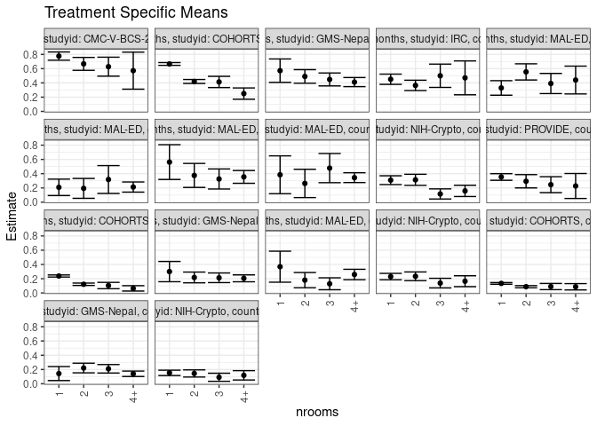

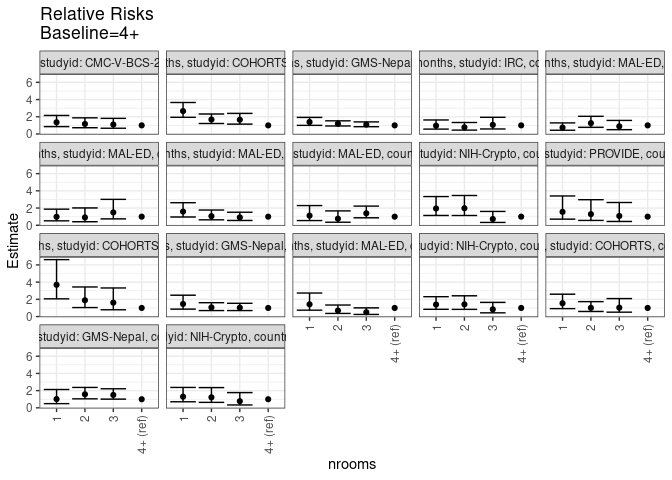

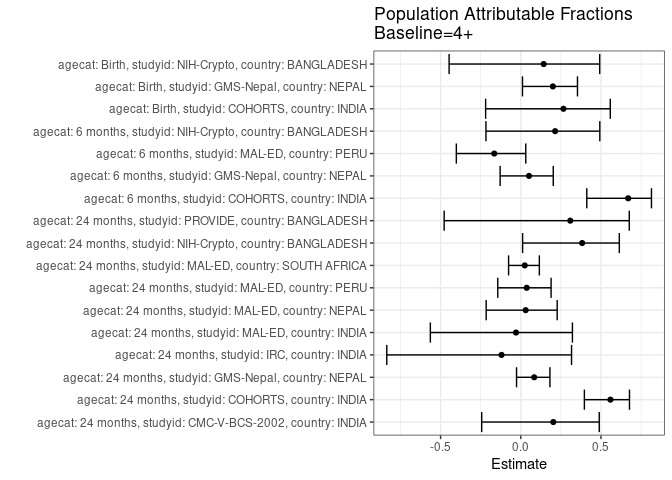

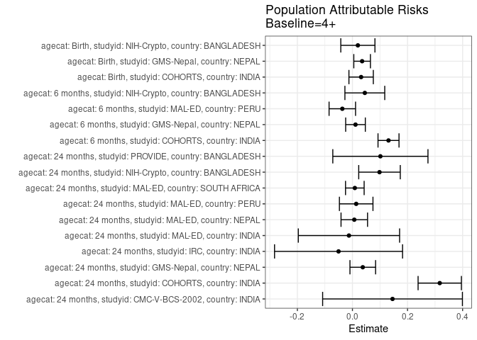

## Results Table

### Parameter: TSM

| agecat | studyid | country | intervention_level | baseline_level | estimate | ci_lower | ci_upper |
| --- | --- | --- | --- | --- | --- | --- | --- |
| Birth | COHORTS | INDIA | 4+ | NA | 0.0869565 | 0.0425224 | 0.1313907 |
| Birth | COHORTS | INDIA | 1 | NA | 0.1344000 | 0.1224401 | 0.1463599 |
| Birth | COHORTS | INDIA | 2 | NA | 0.0880866 | 0.0731587 | 0.1030146 |
| Birth | COHORTS | INDIA | 3 | NA | 0.0898204 | 0.0464507 | 0.1331901 |
| Birth | GMS-Nepal | NEPAL | 4+ | NA | 0.1401869 | 0.1021799 | 0.1781939 |
| Birth | GMS-Nepal | NEPAL | 1 | NA | 0.1428571 | 0.0448089 | 0.2409054 |
| Birth | GMS-Nepal | NEPAL | 2 | NA | 0.2206897 | 0.1531401 | 0.2882392 |
| Birth | GMS-Nepal | NEPAL | 3 | NA | 0.2099448 | 0.1505699 | 0.2693196 |
| Birth | NIH-Crypto | BANGLADESH | 4+ | NA | 0.1182796 | 0.0526010 | 0.1839582 |
| Birth | NIH-Crypto | BANGLADESH | 1 | NA | 0.1529745 | 0.1153981 | 0.1905509 |
| Birth | NIH-Crypto | BANGLADESH | 2 | NA | 0.1443850 | 0.0939741 | 0.1947959 |
| Birth | NIH-Crypto | BANGLADESH | 3 | NA | 0.0909091 | 0.0342415 | 0.1475767 |
| 6 months | COHORTS | INDIA | 4+ | NA | 0.0645161 | 0.0270802 | 0.1019521 |
| 6 months | COHORTS | INDIA | 1 | NA | 0.2380952 | 0.2233666 | 0.2528239 |
| 6 months | COHORTS | INDIA | 2 | NA | 0.1221167 | 0.1054000 | 0.1388333 |
| 6 months | COHORTS | INDIA | 3 | NA | 0.1043956 | 0.0599677 | 0.1488235 |
| 6 months | GMS-Nepal | NEPAL | 4+ | NA | 0.2052239 | 0.1568287 | 0.2536191 |
| 6 months | GMS-Nepal | NEPAL | 1 | NA | 0.3000000 | 0.1578611 | 0.4421389 |
| 6 months | GMS-Nepal | NEPAL | 2 | NA | 0.2173913 | 0.1419381 | 0.2928446 |
| 6 months | GMS-Nepal | NEPAL | 3 | NA | 0.2127660 | 0.1451535 | 0.2803784 |
| 6 months | MAL-ED | PERU | 4+ | NA | 0.2589928 | 0.1860300 | 0.3319556 |
| 6 months | MAL-ED | PERU | 1 | NA | 0.3684211 | 0.1511194 | 0.5857227 |
| 6 months | MAL-ED | PERU | 2 | NA | 0.1800000 | 0.0733129 | 0.2866871 |
| 6 months | MAL-ED | PERU | 3 | NA | 0.1290323 | 0.0454319 | 0.2126326 |
| 6 months | NIH-Crypto | BANGLADESH | 4+ | NA | 0.1648352 | 0.0885496 | 0.2411207 |
| 6 months | NIH-Crypto | BANGLADESH | 1 | NA | 0.2300885 | 0.1852532 | 0.2749238 |
| 6 months | NIH-Crypto | BANGLADESH | 2 | NA | 0.2336957 | 0.1725073 | 0.2948840 |
| 6 months | NIH-Crypto | BANGLADESH | 3 | NA | 0.1386139 | 0.0711776 | 0.2060501 |
| 24 months | CMC-V-BCS-2002 | INDIA | 4+ | NA | 0.5714286 | 0.3118536 | 0.8310035 |
| 24 months | CMC-V-BCS-2002 | INDIA | 1 | NA | 0.7761194 | 0.7184150 | 0.8338238 |
| 24 months | CMC-V-BCS-2002 | INDIA | 2 | NA | 0.6666667 | 0.5763780 | 0.7569553 |
| 24 months | CMC-V-BCS-2002 | INDIA | 3 | NA | 0.6274510 | 0.4945798 | 0.7603221 |
| 24 months | COHORTS | INDIA | 4+ | NA | 0.2500000 | 0.1709857 | 0.3290143 |
| 24 months | COHORTS | INDIA | 1 | NA | 0.6655067 | 0.6462179 | 0.6847956 |
| 24 months | COHORTS | INDIA | 2 | NA | 0.4201474 | 0.3924584 | 0.4478365 |
| 24 months | COHORTS | INDIA | 3 | NA | 0.4133333 | 0.3345188 | 0.4921479 |
| 24 months | GMS-Nepal | NEPAL | 4+ | NA | 0.4112554 | 0.3477359 | 0.4747749 |
| 24 months | GMS-Nepal | NEPAL | 1 | NA | 0.5714286 | 0.4073121 | 0.7355450 |
| 24 months | GMS-Nepal | NEPAL | 2 | NA | 0.4905660 | 0.3953011 | 0.5858310 |
| 24 months | GMS-Nepal | NEPAL | 3 | NA | 0.4482759 | 0.3576821 | 0.5388696 |
| 24 months | IRC | INDIA | 4+ | NA | 0.4705882 | 0.2330272 | 0.7081492 |
| 24 months | IRC | INDIA | 1 | NA | 0.4510870 | 0.3790998 | 0.5230742 |
| 24 months | IRC | INDIA | 2 | NA | 0.3647059 | 0.2922595 | 0.4371523 |
| 24 months | IRC | INDIA | 3 | NA | 0.5000000 | 0.3364686 | 0.6635314 |
| 24 months | MAL-ED | INDIA | 4+ | NA | 0.4400000 | 0.2449899 | 0.6350101 |
| 24 months | MAL-ED | INDIA | 1 | NA | 0.3292683 | 0.2273272 | 0.4312094 |
| 24 months | MAL-ED | INDIA | 2 | NA | 0.5540541 | 0.4405509 | 0.6675573 |
| 24 months | MAL-ED | INDIA | 3 | NA | 0.3913043 | 0.2499578 | 0.5326509 |
| 24 months | MAL-ED | NEPAL | 4+ | NA | 0.2125984 | 0.1412838 | 0.2839131 |
| 24 months | MAL-ED | NEPAL | 1 | NA | 0.2083333 | 0.0931917 | 0.3234750 |
| 24 months | MAL-ED | NEPAL | 2 | NA | 0.1935484 | 0.0541667 | 0.3329301 |
| 24 months | MAL-ED | NEPAL | 3 | NA | 0.3181818 | 0.1231241 | 0.5132396 |
| 24 months | MAL-ED | PERU | 4+ | NA | 0.3545455 | 0.2649257 | 0.4441652 |
| 24 months | MAL-ED | PERU | 1 | NA | 0.5625000 | 0.3188191 | 0.8061809 |
| 24 months | MAL-ED | PERU | 2 | NA | 0.3750000 | 0.2068442 | 0.5431558 |
| 24 months | MAL-ED | PERU | 3 | NA | 0.3255814 | 0.1851735 | 0.4659893 |
| 24 months | MAL-ED | SOUTH AFRICA | 4+ | NA | 0.3442623 | 0.2752786 | 0.4132460 |
| 24 months | MAL-ED | SOUTH AFRICA | 1 | NA | 0.3846154 | 0.1195962 | 0.6496346 |
| 24 months | MAL-ED | SOUTH AFRICA | 2 | NA | 0.2631579 | 0.0647399 | 0.4615759 |
| 24 months | MAL-ED | SOUTH AFRICA | 3 | NA | 0.4782609 | 0.2736835 | 0.6828382 |
| 24 months | NIH-Crypto | BANGLADESH | 4+ | NA | 0.1585366 | 0.0794056 | 0.2376675 |
| 24 months | NIH-Crypto | BANGLADESH | 1 | NA | 0.3087558 | 0.2472290 | 0.3702826 |
| 24 months | NIH-Crypto | BANGLADESH | 2 | NA | 0.3138686 | 0.2360850 | 0.3916523 |
| 24 months | NIH-Crypto | BANGLADESH | 3 | NA | 0.1153846 | 0.0444146 | 0.1863546 |
| 24 months | PROVIDE | BANGLADESH | 4+ | NA | 0.2272727 | 0.0520060 | 0.4025395 |
| 24 months | PROVIDE | BANGLADESH | 1 | NA | 0.3538084 | 0.3073149 | 0.4003018 |
| 24 months | PROVIDE | BANGLADESH | 2 | NA | 0.2934783 | 0.2003501 | 0.3866064 |
| 24 months | PROVIDE | BANGLADESH | 3 | NA | 0.2456140 | 0.1337707 | 0.3574574 |

### Parameter: E(Y)

| agecat | studyid | country | intervention_level | baseline_level | estimate | ci_lower | ci_upper |
| --- | --- | --- | --- | --- | --- | --- | --- |
| Birth | COHORTS | INDIA | NA | NA | 0.1184735 | 0.1093005 | 0.1276464 |
| Birth | GMS-Nepal | NEPAL | NA | NA | 0.1752874 | 0.1470202 | 0.2035545 |
| Birth | NIH-Crypto | BANGLADESH | NA | NA | 0.1379781 | 0.1129774 | 0.1629789 |
| 6 months | COHORTS | INDIA | NA | NA | 0.1954857 | 0.1844503 | 0.2065211 |
| 6 months | GMS-Nepal | NEPAL | NA | NA | 0.2163121 | 0.1823021 | 0.2503220 |
| 6 months | MAL-ED | PERU | NA | NA | 0.2222222 | 0.1725409 | 0.2719036 |
| 6 months | NIH-Crypto | BANGLADESH | NA | NA | 0.2097902 | 0.1799252 | 0.2396552 |
| 24 months | CMC-V-BCS-2002 | INDIA | NA | NA | 0.7169811 | 0.6710815 | 0.7628807 |
| 24 months | COHORTS | INDIA | NA | NA | 0.5670048 | 0.5511355 | 0.5828741 |
| 24 months | GMS-Nepal | NEPAL | NA | NA | 0.4487705 | 0.4045970 | 0.4929440 |
| 24 months | IRC | INDIA | NA | NA | 0.4201474 | 0.3721360 | 0.4681589 |
| 24 months | MAL-ED | INDIA | NA | NA | 0.4273128 | 0.3628178 | 0.4918077 |
| 24 months | MAL-ED | NEPAL | NA | NA | 0.2192982 | 0.1654718 | 0.2731246 |
| 24 months | MAL-ED | PERU | NA | NA | 0.3681592 | 0.3013164 | 0.4350020 |
| 24 months | MAL-ED | SOUTH AFRICA | NA | NA | 0.3529412 | 0.2921001 | 0.4137823 |
| 24 months | NIH-Crypto | BANGLADESH | NA | NA | 0.2568093 | 0.2190047 | 0.2946140 |
| 24 months | PROVIDE | BANGLADESH | NA | NA | 0.3287197 | 0.2903909 | 0.3670485 |

### Parameter: RR

| agecat | studyid | country | intervention_level | baseline_level | estimate | ci_lower | ci_upper |
| --- | --- | --- | --- | --- | --- | --- | --- |
| Birth | COHORTS | INDIA | 4+ | 4+ | 1.0000000 | 1.0000000 | 1.000000 |
| Birth | COHORTS | INDIA | 1 | 4+ | 1.5456000 | 0.9201016 | 2.596321 |
| Birth | COHORTS | INDIA | 2 | 4+ | 1.0129964 | 0.5912897 | 1.735464 |
| Birth | COHORTS | INDIA | 3 | 4+ | 1.0329341 | 0.5113859 | 2.086395 |
| Birth | GMS-Nepal | NEPAL | 4+ | 4+ | 1.0000000 | 1.0000000 | 1.000000 |
| Birth | GMS-Nepal | NEPAL | 1 | 4+ | 1.0190476 | 0.4872017 | 2.131475 |
| Birth | GMS-Nepal | NEPAL | 2 | 4+ | 1.5742529 | 1.0459129 | 2.369482 |
| Birth | GMS-Nepal | NEPAL | 3 | 4+ | 1.4976059 | 1.0121675 | 2.215862 |
| Birth | NIH-Crypto | BANGLADESH | 4+ | 4+ | 1.0000000 | 1.0000000 | 1.000000 |
| Birth | NIH-Crypto | BANGLADESH | 1 | 4+ | 1.2933299 | 0.7047110 | 2.373600 |
| Birth | NIH-Crypto | BANGLADESH | 2 | 4+ | 1.2207098 | 0.6335011 | 2.352218 |
| Birth | NIH-Crypto | BANGLADESH | 3 | 4+ | 0.7685950 | 0.3335395 | 1.771119 |
| 6 months | COHORTS | INDIA | 4+ | 4+ | 1.0000000 | 1.0000000 | 1.000000 |
| 6 months | COHORTS | INDIA | 1 | 4+ | 3.6904762 | 2.0589789 | 6.614742 |
| 6 months | COHORTS | INDIA | 2 | 4+ | 1.8928087 | 1.0427652 | 3.435792 |
| 6 months | COHORTS | INDIA | 3 | 4+ | 1.6181319 | 0.7879522 | 3.322982 |
| 6 months | GMS-Nepal | NEPAL | 4+ | 4+ | 1.0000000 | 1.0000000 | 1.000000 |
| 6 months | GMS-Nepal | NEPAL | 1 | 4+ | 1.4618182 | 0.8610895 | 2.481638 |
| 6 months | GMS-Nepal | NEPAL | 2 | 4+ | 1.0592885 | 0.6962696 | 1.611577 |
| 6 months | GMS-Nepal | NEPAL | 3 | 4+ | 1.0367505 | 0.6979368 | 1.540042 |
| 6 months | MAL-ED | PERU | 4+ | 4+ | 1.0000000 | 1.0000000 | 1.000000 |
| 6 months | MAL-ED | PERU | 1 | 4+ | 1.4225146 | 0.7399163 | 2.734834 |
| 6 months | MAL-ED | PERU | 2 | 4+ | 0.6950000 | 0.3605609 | 1.339649 |
| 6 months | MAL-ED | PERU | 3 | 4+ | 0.4982079 | 0.2457997 | 1.009810 |
| 6 months | NIH-Crypto | BANGLADESH | 4+ | 4+ | 1.0000000 | 1.0000000 | 1.000000 |
| 6 months | NIH-Crypto | BANGLADESH | 1 | 4+ | 1.3958702 | 0.8448204 | 2.306352 |
| 6 months | NIH-Crypto | BANGLADESH | 2 | 4+ | 1.4177536 | 0.8330538 | 2.412840 |
| 6 months | NIH-Crypto | BANGLADESH | 3 | 4+ | 0.8409241 | 0.4296767 | 1.645780 |
| 24 months | CMC-V-BCS-2002 | INDIA | 4+ | 4+ | 1.0000000 | 1.0000000 | 1.000000 |
| 24 months | CMC-V-BCS-2002 | INDIA | 1 | 4+ | 1.3582090 | 0.8571575 | 2.152150 |
| 24 months | CMC-V-BCS-2002 | INDIA | 2 | 4+ | 1.1666667 | 0.7262472 | 1.874171 |
| 24 months | CMC-V-BCS-2002 | INDIA | 3 | 4+ | 1.0980392 | 0.6652018 | 1.812518 |
| 24 months | COHORTS | INDIA | 4+ | 4+ | 1.0000000 | 1.0000000 | 1.000000 |
| 24 months | COHORTS | INDIA | 1 | 4+ | 2.6620270 | 1.9380929 | 3.656371 |
| 24 months | COHORTS | INDIA | 2 | 4+ | 1.6805897 | 1.2168794 | 2.321004 |
| 24 months | COHORTS | INDIA | 3 | 4+ | 1.6533333 | 1.1430171 | 2.391488 |
| 24 months | GMS-Nepal | NEPAL | 4+ | 4+ | 1.0000000 | 1.0000000 | 1.000000 |
| 24 months | GMS-Nepal | NEPAL | 1 | 4+ | 1.3894737 | 1.0028284 | 1.925192 |
| 24 months | GMS-Nepal | NEPAL | 2 | 4+ | 1.1928500 | 0.9307344 | 1.528783 |
| 24 months | GMS-Nepal | NEPAL | 3 | 4+ | 1.0900181 | 0.8452164 | 1.405722 |
| 24 months | IRC | INDIA | 4+ | 4+ | 1.0000000 | 1.0000000 | 1.000000 |
| 24 months | IRC | INDIA | 1 | 4+ | 0.9585598 | 0.5645284 | 1.627619 |
| 24 months | IRC | INDIA | 2 | 4+ | 0.7750000 | 0.4505050 | 1.333226 |
| 24 months | IRC | INDIA | 3 | 4+ | 1.0625000 | 0.5822344 | 1.938921 |
| 24 months | MAL-ED | INDIA | 4+ | 4+ | 1.0000000 | 1.0000000 | 1.000000 |
| 24 months | MAL-ED | INDIA | 1 | 4+ | 0.7483370 | 0.4358170 | 1.284962 |
| 24 months | MAL-ED | INDIA | 2 | 4+ | 1.2592138 | 0.7727710 | 2.051862 |
| 24 months | MAL-ED | INDIA | 3 | 4+ | 0.8893281 | 0.5020532 | 1.575340 |
| 24 months | MAL-ED | NEPAL | 4+ | 4+ | 1.0000000 | 1.0000000 | 1.000000 |
| 24 months | MAL-ED | NEPAL | 1 | 4+ | 0.9799383 | 0.5133603 | 1.870575 |
| 24 months | MAL-ED | NEPAL | 2 | 4+ | 0.9103943 | 0.4113507 | 2.014869 |
| 24 months | MAL-ED | NEPAL | 3 | 4+ | 1.4966330 | 0.7440893 | 3.010271 |
| 24 months | MAL-ED | PERU | 4+ | 4+ | 1.0000000 | 1.0000000 | 1.000000 |
| 24 months | MAL-ED | PERU | 1 | 4+ | 1.5865385 | 0.9607811 | 2.619852 |
| 24 months | MAL-ED | PERU | 2 | 4+ | 1.0576923 | 0.6321278 | 1.769758 |
| 24 months | MAL-ED | PERU | 3 | 4+ | 0.9183065 | 0.5570516 | 1.513840 |
| 24 months | MAL-ED | SOUTH AFRICA | 4+ | 4+ | 1.0000000 | 1.0000000 | 1.000000 |
| 24 months | MAL-ED | SOUTH AFRICA | 1 | 4+ | 1.1172161 | 0.5451169 | 2.289732 |
| 24 months | MAL-ED | SOUTH AFRICA | 2 | 4+ | 0.7644110 | 0.3503542 | 1.667810 |
| 24 months | MAL-ED | SOUTH AFRICA | 3 | 4+ | 1.3892340 | 0.8662267 | 2.228021 |
| 24 months | NIH-Crypto | BANGLADESH | 4+ | 4+ | 1.0000000 | 1.0000000 | 1.000000 |
| 24 months | NIH-Crypto | BANGLADESH | 1 | 4+ | 1.9475363 | 1.1378298 | 3.333449 |
| 24 months | NIH-Crypto | BANGLADESH | 2 | 4+ | 1.9797866 | 1.1339631 | 3.456510 |
| 24 months | NIH-Crypto | BANGLADESH | 3 | 4+ | 0.7278107 | 0.3296145 | 1.607054 |
| 24 months | PROVIDE | BANGLADESH | 4+ | 4+ | 1.0000000 | 1.0000000 | 1.000000 |
| 24 months | PROVIDE | BANGLADESH | 1 | 4+ | 1.5567568 | 0.7119946 | 3.403806 |
| 24 months | PROVIDE | BANGLADESH | 2 | 4+ | 1.2913043 | 0.5608755 | 2.972971 |
| 24 months | PROVIDE | BANGLADESH | 3 | 4+ | 1.0807018 | 0.4413269 | 2.646375 |

### Parameter: PAR

| agecat | studyid | country | intervention_level | baseline_level | estimate | ci_lower | ci_upper |
| --- | --- | --- | --- | --- | --- | --- | --- |
| Birth | COHORTS | INDIA | 4+ | NA | 0.0315170 | -0.0127529 | 0.0757868 |
| Birth | GMS-Nepal | NEPAL | 4+ | NA | 0.0351004 | 0.0049159 | 0.0652850 |
| Birth | NIH-Crypto | BANGLADESH | 4+ | NA | 0.0196986 | -0.0422903 | 0.0816874 |
| 6 months | COHORTS | INDIA | 4+ | NA | 0.1309696 | 0.0928493 | 0.1690899 |
| 6 months | GMS-Nepal | NEPAL | 4+ | NA | 0.0110882 | -0.0245903 | 0.0467666 |
| 6 months | MAL-ED | PERU | 4+ | NA | -0.0367706 | -0.0848383 | 0.0112971 |
| 6 months | NIH-Crypto | BANGLADESH | 4+ | NA | 0.0449550 | -0.0273643 | 0.1172744 |
| 24 months | CMC-V-BCS-2002 | INDIA | 4+ | NA | 0.1455526 | -0.1082204 | 0.3993255 |
| 24 months | COHORTS | INDIA | 4+ | NA | 0.3170048 | 0.2383732 | 0.3956364 |
| 24 months | GMS-Nepal | NEPAL | 4+ | NA | 0.0375151 | -0.0090281 | 0.0840582 |
| 24 months | IRC | INDIA | 4+ | NA | -0.0504408 | -0.2828754 | 0.1819938 |
| 24 months | MAL-ED | INDIA | 4+ | NA | -0.0126872 | -0.1965680 | 0.1711935 |
| 24 months | MAL-ED | NEPAL | 4+ | NA | 0.0066998 | -0.0414388 | 0.0548384 |
| 24 months | MAL-ED | PERU | 4+ | NA | 0.0136137 | -0.0472857 | 0.0745132 |
| 24 months | MAL-ED | SOUTH AFRICA | 4+ | NA | 0.0086789 | -0.0251192 | 0.0424769 |
| 24 months | NIH-Crypto | BANGLADESH | 4+ | NA | 0.0982728 | 0.0228208 | 0.1737247 |
| 24 months | PROVIDE | BANGLADESH | 4+ | NA | 0.1014470 | -0.0713219 | 0.2742159 |

### Parameter: PAF

| agecat | studyid | country | intervention_level | baseline_level | estimate | ci_lower | ci_upper |
| --- | --- | --- | --- | --- | --- | --- | --- |
| Birth | COHORTS | INDIA | 4+ | NA | 0.2660254 | -0.2191932 | 0.5581351 |
| Birth | GMS-Nepal | NEPAL | 4+ | NA | 0.2002451 | 0.0105904 | 0.3535460 |
| Birth | NIH-Crypto | BANGLADESH | 4+ | NA | 0.1427659 | -0.4468845 | 0.4921154 |
| 6 months | COHORTS | INDIA | 4+ | NA | 0.6699701 | 0.4116068 | 0.8148861 |
| 6 months | GMS-Nepal | NEPAL | 4+ | NA | 0.0512601 | -0.1287737 | 0.2025794 |
| 6 months | MAL-ED | PERU | 4+ | NA | -0.1654676 | -0.4018717 | 0.0310705 |
| 6 months | NIH-Crypto | BANGLADESH | 4+ | NA | 0.2142857 | -0.2172239 | 0.4928238 |
| 24 months | CMC-V-BCS-2002 | INDIA | 4+ | NA | 0.2030075 | -0.2437129 | 0.4892736 |
| 24 months | COHORTS | INDIA | 4+ | NA | 0.5590866 | 0.3965562 | 0.6778414 |
| 24 months | GMS-Nepal | NEPAL | 4+ | NA | 0.0835952 | -0.0263937 | 0.1817977 |
| 24 months | IRC | INDIA | 4+ | NA | -0.1200550 | -0.8356451 | 0.3165763 |
| 24 months | MAL-ED | INDIA | 4+ | NA | -0.0296907 | -0.5638980 | 0.3220383 |
| 24 months | MAL-ED | NEPAL | 4+ | NA | 0.0305512 | -0.2157265 | 0.2269388 |
| 24 months | MAL-ED | PERU | 4+ | NA | 0.0369779 | -0.1435142 | 0.1889812 |
| 24 months | MAL-ED | SOUTH AFRICA | 4+ | NA | 0.0245902 | -0.0760360 | 0.1158062 |
| 24 months | NIH-Crypto | BANGLADESH | 4+ | NA | 0.3826681 | 0.0113978 | 0.6145076 |
| 24 months | PROVIDE | BANGLADESH | 4+ | NA | 0.3086124 | -0.4777979 | 0.6765344 |